# Manipuler les vecteurs avec `R` et le package `sf`

GEO UNIV’R Tunisie 2024

Author

Elina Marveaux, Nicolas Lambert, Ronan Ysebaert

Published

February 24, 2025

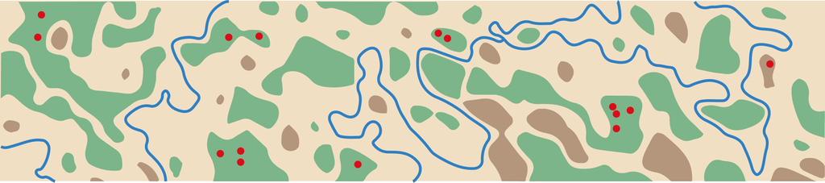

**Note**

Ce support est inspiré en de nombreux points du manuel [Géomatique avec R](https://rcarto.github.io/geomatique_avec_r/) (Giraud and Pecout (2024)). Les exemples proposés sont tantôt adaptés aux contexte tunisien ou au contexte africain. On les en remercie chaleureusement 🙏

### Packages utilisés

- **`readxl`** : importer des fichiers Excel.
- **`sf`** : importer, manipuler et exporter des données géographiques vectorielles.
- **`mapsf`** : cartographie thématique
- **`units`** : Manipuler les unités des objets R
- **`dplyr`** : Manipuler les données
- **`rmapshaper`** : simplifier des géométries
- **`terra`** : importer, manipuler et exporter des fichiers raster.

Si vous n’avez pas ces packages, vous pouvez les installer en exécutant la ligne suivante dans la console.

```r
install.packages(c('readxl', 'sf', 'dplyr', 'units', 'rmapshaper', 'mapsf'))
```

# Les formats vectoriels - *un retour rapide*

Les données spatiales vectorielles correspondent à une géométrie qui peut être ponctuelle, linéaire ou zonale. Plusieurs formats de données géospatiales existent : shapefile (shp), GeoPackage (GPKG), GeoJSON (geojson), sqlite (sqlite), geodatabase d’ESRI (FileGDB), etc…

Nous nous attardons rapidement ici aux deux formats utilisés dans cette école d’été, le shapefile (shp) et le GéoPackage (gpkg).

## Le shapefile

Le shapefile est un format de données spatiales vectorielles propriétaire édité par l’entreprise ESRI, il se présente comme une collection de fichiers portant le même nom avec les extensions et les usages suivants :

- `.shp` : stocke le format de la forme, sa géométrie
- `.dbf` : données attributaires relatives aux géométries du `.shp` contenus dans le shapefile ;
- `.shx` : index de la géométrie.
- `.prj` : système de coordonnées au format WKT (well-known text)

Chaque fichier doit porter le même nom et est indispensable au bon fonctionnement du shapefile.

D’autres fichiers annexes peuvent aussi être fournis ou générés (indexes de formes, d’attributs, métadonnées au format xml…).

## Le GeoPackage

Le GeoPackage est un format de données spatiales vectorielles et raster non propriétaire et défini selon les standards de l’Open Geospatial Consortium (OGC). Il se comprend comme un fichier base de données qui peut contenir des objets vectoriels, les tuiles d’images, des données raster, des schémas de métadonnées comme ceux des normes INSPIRE.

Hormis le format ouvert et l’interopérabilité, l’avantage du géopackage est qu’il peut se requêter comme une base de données avec du SQL dans QGIs, R ou ailleurs, et qu’il peut stocker dans un même fichier plusieurs couches raster ou vecteur. Cela facilite grandement l’organisation et la gestion de projets en géomatique.

On peut par exemple organiser son travail autour du GeoPackage de différente façon :

- un géopagkage par projet
- un géopackage par echelle ou zone de travail (monde, tunisie)
- un géopagkage par type d’utilisation (géotraitements et versionnage ou cartographie)

La figure suivante illustre la différence d’organisation ou d’arborescence fichiers dans le cas d’utilisation de fichiers au format shapefile ou GéoPackage

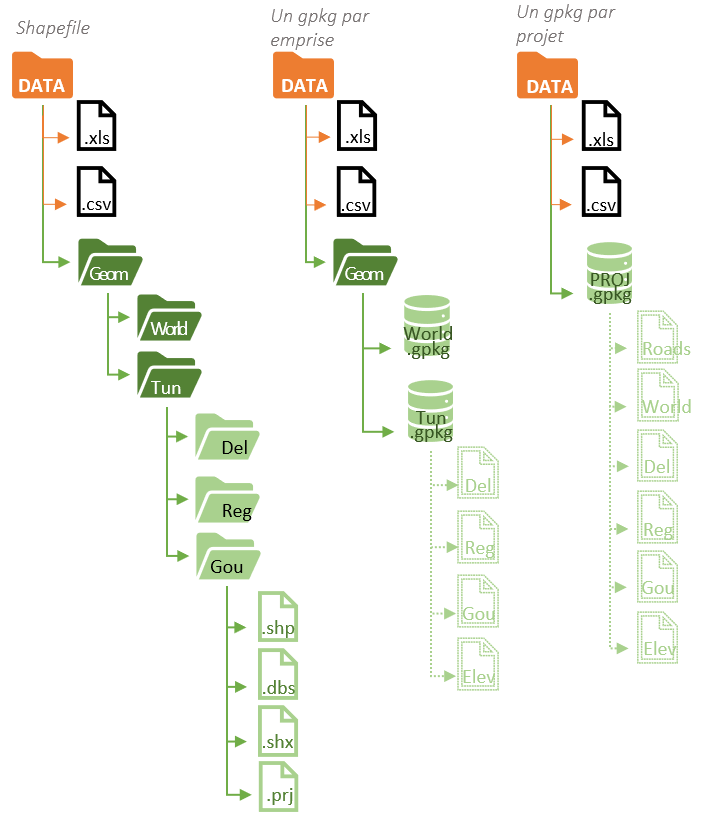

# Le package `sf`

[figure not shown]

Le package `sf` (Pebesma and Bivand 2023), publié en 2016 par Edzer Pebesma permet l’import, l’export, la manipulation et l’affichage de données spatiales vectorielles. Pour cela `sf` s’appuie sur une série de bibliothèques spatiales : GDAL (GDAL/OGR contributors, 2022), PROJ (PROJ contributors, 2021) pour les opérations d’import, d’export et de projection, et GEOS (GEOS contributors, 2021) pour les opérations de géotraitement (buffer, intersection…). Ce package propose des objets simples (suivant le standard simple feature) dont la manipulation est assez aisée. Une attention particulière a été portée à la compatibilité du package avec la syntaxe pipe (|> ou %>%) et les opérateurs du tidyverse (Wickham et al., 2019).

## Anatomie d’un objet sf

Un objet sf se présente comme un tableau de données `data.frame`, soit comme une table attributaire, à laquelle on ajoute une colonne *geom* ou *geometry* spécifique, de classe `sfc` (simple feature column) contenant les géométries (simple feature geometry). Chaque ligne, chaque individu est appelé simple feature.

Dans l’écosystème R, le `data.frame` est conçu comme une structure de vecteurs. Chaque colonne correspond à un vecteur et peut donc prendre tous les types que peuvent prendre des vecteurs (character, integer, numeric, boolean etc…). On peut donc effectuer sur les objets sf les même manipulations que l’on fait sur les vecteurs et tableaux dans R.

La colonne contenant les géométries peut quant à elle prendre les types de géométrie traditionnels pris en charge par les [GeoJSON](https://www.rfc-editor.org/rfc/rfc7946) :

| type | description |
| --- | --- |
| `POINT` | géométrie à zéro dimension contenant un seul point |
| `LINESTRING` | séquence de points reliés par des morceaux de lignes droites qui ne se coupent pas entre elles ; géométrie unidimensionnelle |
| `POLYGON` | Géométrie à aire positive (bidimensionnelle) ; une séquence de points forme un anneau fermé, non auto-intersecté ; le premier anneau désigne l’anneau extérieur, zéro ou plusieurs anneaux suivants dési… |
| `MULTIPOINT` | ensemble de points ; un MULTIPOINT est simple si aucun des points du MULTIPOINT n’est égal. |
| `MULTILINESTRING` | ensemble de `LINESTRING` |
| `MULTIPOLYGON` | ensemble de `POLYGON` |
| `GEOMETRYCOLLECTION` | ensemble de géométries de tout type sauf `GEOMETRYCOLLECTION` |

Cette colonne se prête aux géotraitements typiques d’un SIG comme le buffer, l’intersection ou l’agrégation.

## Importer et Exporter des données spatiales vectorielles avec `sf`

### Importer des données

Chargement de la librairie

```r
library("sf")
```

La fonction `st_read()` de `sf` permet d’importer des formats de données géographiques variés (shapefile `.shp`, GeoPackage `.GPKG`, GeoJSON `.geojson` …). Avant l’importation d’un fichier au format Geopackage il est préconnisé de consulter le contenu du fichier.

Pour cela on utilise la fonction `st_layers()`

```r
st_layers("data/tun/geom/tun_admin.gpkg")
```

```
Driver: GPKG
Available layers:
   layer_name geometry_type features fields                      crs_name
1  delegation Multi Polygon      266     11 ETRS89-extended / LAEA Europe
2 gouvernorat Multi Polygon       24      4 ETRS89-extended / LAEA Europe
3      region Multi Polygon        6      2 ETRS89-extended / LAEA Europe
```

Cette fonction nous donne quelques résumés sur chacune des couches du GeoPackage. Le nom, le type de géométrie, le nombre d’individus, le nombre de champs, et le CRS, la projection de chaque couche.

Nous pouvons à présent importer la couche “delegation” dans l’objet “del”

```r
del <- st_read(dsn = "data/tun/geom/tun_admin.gpkg",
               layer = "delegation")
```

## Exporter des données

`sf` peut lire plusieurs formats géospatiaux et peut donc tout autant écrire ces formats à l’aide de la fonction `st_write()`.

Cette fonction prend trois paramètres indispensables en entrée, l’objet à écrire `obj =`, son chemin d’écriture `dsn =`, la couche à écrire`layer =`.

Pour l’exercice nous allons construire un GeoPackage de projet nommé `mar1Vector.gpkg`, dans lequel nous allons enregistrer notre couche `del`.

```r
st_write(obj = del,
         dsn = "data/mar1Vector.gpkg",
         layer = "delegation")
```

Remarquez qu’ici le chemin d’accès prend le nom complet du fichier et son extension. Ici le nom du GeoPackage et l’extension `.gpkg`. Si nous avions voulu exporter un GeoJSON, nous aurions écrit `dsn = delegation.geojson`

Quelques paramètres additionnels sont utiles à connaître. Par exemple pour “écraser” ou remplacer une couche déja existante on utilise l’argument `delete_layer = TRUE`, lorsqu’il s’agit de remplacer le fichier `delete_dsn = TRUE`.

```r
st_write(obj = del,
         dsn = "data/mar1Vector.gpkg",
         layer = "delegation",
         delete_layer = TRUE)
```

D’autres paramétrages sont possibles pour les autres types d’exports, pour cela référez-vous à la [vignette du package](https://r-spatial.github.io/sf/reference/st_write.html)

# Premieres explorations

## L’objet et la table attributaire (le `data.frame`)

Puisque l’objet `sf` est un `data.frame`, on peut faire des opérations typiques telles que :

`head()` pour en visualiser un extrait :

```r
head(del)
```

```
Simple feature collection with 6 features and 11 fields
Geometry type: MULTIPOLYGON
Dimension:     XY
Bounding box:  xmin: 4184398 ymin: 1282883 xmax: 4380989 ymax: 1539573
Projected CRS: ETRS89-extended / LAEA Europe
  del_code   del_nom_fr del_code_riate del_code_ins     del_nom_ar gou_code
1 TN.SF.AG       Agareb         TS2146        TN347          عقارب    TN.SF
2 TN.JE.AD   Ain Drahem         TS1224        TN225      عين دراهم    TN.JE
3 TN.SS.AK       Akouda         TS2115        TN316          اكودة    TN.SS
4 TN.KR.AL         Alaa         TS2216        TN417         العلاء    TN.KR
5 TN.BJ.AM       Amdoun         TS1212        TN213          عمدون    TN.BJ
6 TN.AN.AR Ariana Ville         TS1120        TN121 أريانة المدينة    TN.AN
   gou_nom gou_cap gou_cap_dist reg_code      reg_nom
1     Sfax       0         30.1       CE   Centre-est
2 Jendouba       0         38.5       NO   Nord-ouest
3   Sousse       0         14.3       CE   Centre-est
4 Kairouan       0         48.6       CO Centre-ouest
5     Beja       0         18.9       NO   Nord-ouest
6   Ariana       1          1.0       NE     Nord-est
                            geom
1 MULTIPOLYGON (((4375308 130...
2 MULTIPOLYGON (((4224769 152...
3 MULTIPOLYGON (((4373533 142...
4 MULTIPOLYGON (((4306097 141...
5 MULTIPOLYGON (((4243838 153...
6 MULTIPOLYGON (((4338370 153...
```

`str()` pour connaitre le type ou la classe de chaque champ :

```r
str(del)
```

```
Classes 'sf' and 'data.frame':  266 obs. of  12 variables:
 $ del_code      : chr  "TN.SF.AG" "TN.JE.AD" "TN.SS.AK" "TN.KR.AL" ...
 $ del_nom_fr    : chr  "Agareb" "Ain Drahem" "Akouda" "Alaa" ...
 $ del_code_riate: chr  "TS2146" "TS1224" "TS2115" "TS2216" ...
 $ del_code_ins  : chr  "TN347" "TN225" "TN316" "TN417" ...
 $ del_nom_ar    : chr  "عقارب" "عين دراهم" "اكودة" "العلاء" ...
 $ gou_code      : chr  "TN.SF" "TN.JE" "TN.SS" "TN.KR" ...
 $ gou_nom       : chr  "Sfax" "Jendouba" "Sousse" "Kairouan" ...
 $ gou_cap       : int  0 0 0 0 0 1 0 0 0 0 ...
 $ gou_cap_dist  : num  30.1 38.5 14.3 48.6 18.9 1 36.6 15.5 17.1 28.9 ...
 $ reg_code      : chr  "CE" "NO" "CE" "CO" ...
 $ reg_nom       : chr  "Centre-est" "Nord-ouest" "Centre-est" "Centre-ouest" ...
 $ geom          :sfc_MULTIPOLYGON of length 266; first list element: List of 1
  ..$ :List of 1
  .. ..$ : num [1:204, 1:2] 4375308 4375308 4379546 4379546 4379546 ...
  ..- attr(*, "class")= chr [1:3] "XY" "MULTIPOLYGON" "sfg"
 - attr(*, "sf_column")= chr "geom"
 - attr(*, "agr")= Factor w/ 3 levels "constant","aggregate",..: NA NA NA NA NA NA NA NA NA NA ...
  ..- attr(*, "names")= chr [1:11] "del_code" "del_nom_fr" "del_code_riate" "del_code_ins" ...
```

`colnames()` pour connaitre le nom chaque champ :

```r
colnames(del)
```

```
 [1] "del_code"       "del_nom_fr"     "del_code_riate" "del_code_ins"
 [5] "del_nom_ar"     "gou_code"       "gou_nom"        "gou_cap"
 [9] "gou_cap_dist"   "reg_code"       "reg_nom"        "geom"
```

ou `summary()` pour avoir un résumé statistique de chaque champ :

```r
summary(del)
```

```
   del_code          del_nom_fr        del_code_riate     del_code_ins
 Length:266         Length:266         Length:266         Length:266
 Class :character   Class :character   Class :character   Class :character
 Mode  :character   Mode  :character   Mode  :character   Mode  :character



  del_nom_ar          gou_code           gou_nom             gou_cap
 Length:266         Length:266         Length:266         Min.   :0.00000
 Class :character   Class :character   Class :character   1st Qu.:0.00000
 Mode  :character   Mode  :character   Mode  :character   Median :0.00000
                                                          Mean   :0.09023
                                                          3rd Qu.:0.00000
                                                          Max.   :1.00000
  gou_cap_dist      reg_code           reg_nom                     geom
 Min.   :  1.00   Length:266         Length:266         MULTIPOLYGON :266
 1st Qu.: 14.32   Class :character   Class :character   epsg:3035    :  0
 Median : 24.40   Mode  :character   Mode  :character   +proj=laea...:  0
 Mean   : 28.66
 3rd Qu.: 41.38
 Max.   :147.40
```

## Les géométries

Pour connaitre le type de géométries on utilise la fonction `st_geometry_type()`. On peut rajouter l’argument `by_geometry = FALSE` pour avoir le type de l’ensemble.

```r
st_geometry_type(del, by_geometry = FALSE)
```

```
[1] MULTIPOLYGON
18 Levels: GEOMETRY POINT LINESTRING POLYGON MULTIPOINT ... TRIANGLE
```

On peut aussi visualiser les géométries avec la fonction `plot()` native de R.

Dans ce premier cas on obtient une carte par champs de la table attributaire

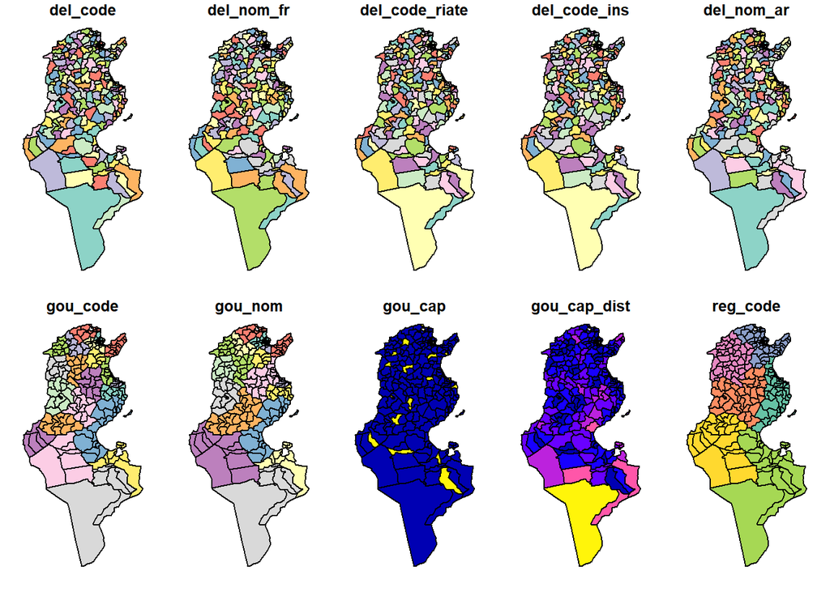

```r
plot(del)
```

Il existe deux façons de ne veut visualiser que les géométries

la fonction `st_geometry()` qui renvoi uniquement aux géométrie de l’objet sf

`plot(st_geometry(del))`

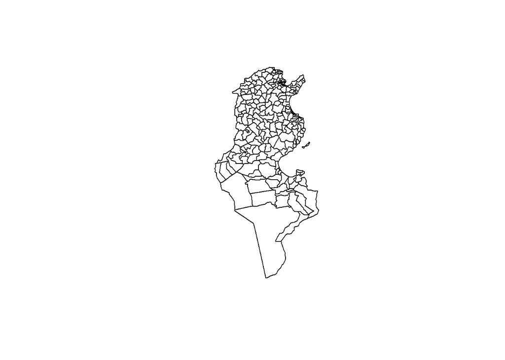

ou on sélectionne le champs contenant les géométries

`plot(del$geom)`

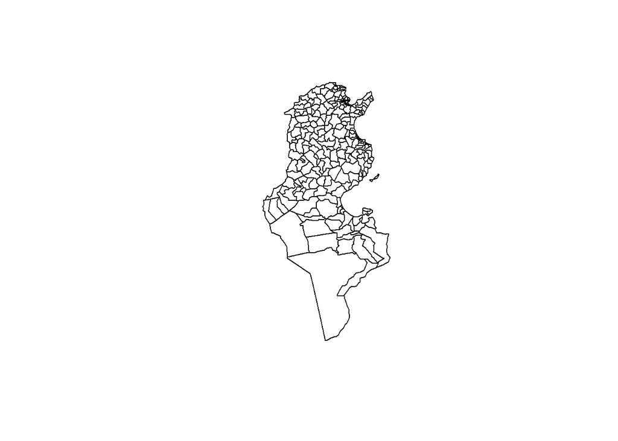

**Tip**

Pour plus de détail sur la cartographie avec le package sf voir le notebook de N. Lambert conçu pour l’école thématique : [Faire des cartes thématiques avec R](https://neocarto.github.io/geounivr2024/MAR_2_carto/index.html#cartographie-avec-sf)

# Les systèmes de coordonnées

Pour connaître le détail du système de coordonnées de référence d’un objet `sf` on utilise la fonction `st_crs()`

**Détail de l’exéctution de la fonction st_crs()**

```r
st_crs(del)
```

```
Coordinate Reference System:
  User input: ETRS89-extended / LAEA Europe
  wkt:
PROJCRS["ETRS89-extended / LAEA Europe",
    BASEGEOGCRS["ETRS89",
        ENSEMBLE["European Terrestrial Reference System 1989 ensemble",
            MEMBER["European Terrestrial Reference Frame 1989"],
            MEMBER["European Terrestrial Reference Frame 1990"],
            MEMBER["European Terrestrial Reference Frame 1991"],
            MEMBER["European Terrestrial Reference Frame 1992"],
            MEMBER["European Terrestrial Reference Frame 1993"],
            MEMBER["European Terrestrial Reference Frame 1994"],
            MEMBER["European Terrestrial Reference Frame 1996"],
            MEMBER["European Terrestrial Reference Frame 1997"],
            MEMBER["European Terrestrial Reference Frame 2000"],
            MEMBER["European Terrestrial Reference Frame 2005"],
            MEMBER["European Terrestrial Reference Frame 2014"],
            MEMBER["European Terrestrial Reference Frame 2020"],
            ELLIPSOID["GRS 1980",6378137,298.257222101,
                LENGTHUNIT["metre",1]],
            ENSEMBLEACCURACY[0.1]],
        PRIMEM["Greenwich",0,
            ANGLEUNIT["degree",0.0174532925199433]],
        ID["EPSG",4258]],
    CONVERSION["Europe Equal Area 2001",
        METHOD["Lambert Azimuthal Equal Area",
            ID["EPSG",9820]],
        PARAMETER["Latitude of natural origin",52,
            ANGLEUNIT["degree",0.0174532925199433],
            ID["EPSG",8801]],
        PARAMETER["Longitude of natural origin",10,
            ANGLEUNIT["degree",0.0174532925199433],
            ID["EPSG",8802]],
        PARAMETER["False easting",4321000,
            LENGTHUNIT["metre",1],
            ID["EPSG",8806]],
        PARAMETER["False northing",3210000,
            LENGTHUNIT["metre",1],
            ID["EPSG",8807]]],
    CS[Cartesian,2],
        AXIS["northing (Y)",north,
            ORDER[1],
            LENGTHUNIT["metre",1]],
        AXIS["easting (X)",east,
            ORDER[2],
            LENGTHUNIT["metre",1]],
    USAGE[
        SCOPE["Statistical analysis."],
        AREA["Europe - European Union (EU) countries and candidates. Europe - onshore and offshore: Albania; Andorra; Austria; Belgium; Bosnia and Herzegovina; Bulgaria; Croatia; Cyprus; Czechia; Denmark; Estonia; Faroe Islands; Finland; France; Germany; Gibraltar; Greece; Hungary; Iceland; Ireland;…
        BBOX[24.6,-35.58,84.73,44.83]],
    ID["EPSG",3035]]
```

Ceci nous renvoi la définition complète du système de coordonnées selon les standards en WKT.

Mais on peut aussi récupérer des informations spécifiques relatives à la projection. Pour cela on utilise l’argument `parameters = TRUE`.

Il faut alors soit enregistrer le résultat de cette fonction dans un objet puis acceder aux paramètres via l’objet…

```r
crsDel <- st_crs(del, parameters = TRUE)
```

**Détail de l’objet `crsDel`**

```r
crsDel
```

```
$SemiMajor
6378137 [m]

$SemiMinor
6356752 [m]

$InvFlattening
[1] 298.2572

$IsGeographic
[1] FALSE

$units_gdal
[1] "metre"

$IsVertical
[1] FALSE

$WktPretty
[1] "PROJCS[\"ETRS89-extended / LAEA Europe\",\n    GEOGCS[\"ETRS89\",\n        DATUM[\"European_Terrestrial_Reference_System_1989\",\n            SPHEROID[\"GRS 1980\",6378137,298.257222101]],\n        PRIMEM[\"Greenwich\",0],\n        UNIT[\"degree\",0.0174532925199433,\n            AUTHORITY[\"EP…

$Wkt
[1] "PROJCS[\"ETRS89-extended / LAEA Europe\",GEOGCS[\"ETRS89\",DATUM[\"European_Terrestrial_Reference_System_1989\",SPHEROID[\"GRS 1980\",6378137,298.257222101]],PRIMEM[\"Greenwich\",0],UNIT[\"degree\",0.0174532925199433,AUTHORITY[\"EPSG\",\"9122\"]],AUTHORITY[\"EPSG\",\"4258\"]],PROJECTION[\"Lambe…

$Name
[1] "ETRS89-extended / LAEA Europe"

$proj4string
[1] "+proj=laea +lat_0=52 +lon_0=10 +x_0=4321000 +y_0=3210000 +ellps=GRS80 +units=m +no_defs"

$epsg
[1] 3035

$yx
[1] TRUE

$ProjJson
[1] "{\n  \"$schema\": \"https://proj.org/schemas/v0.7/projjson.schema.json\",\n  \"type\": \"ProjectedCRS\",\n  \"name\": \"ETRS89-extended / LAEA Europe\",\n  \"base_crs\": {\n    \"name\": \"ETRS89\",\n    \"datum_ensemble\": {\n      \"name\": \"European Terrestrial Reference System 1989 ensembl…

$WKT1_ESRI
[1] "PROJCS[\"ETRS_1989_LAEA\",\n    GEOGCS[\"GCS_ETRS_1989\",\n        DATUM[\"D_ETRS_1989\",\n            SPHEROID[\"GRS_1980\",6378137.0,298.257222101]],\n        PRIMEM[\"Greenwich\",0.0],\n        UNIT[\"Degree\",0.0174532925199433]],\n    PROJECTION[\"Lambert_Azimuthal_Equal_Area\"],\n    PARA…

$srid
[1] "EPSG:3035"

$axes
      name orientation
1 Northing           1
2  Easting           3

$ud_unit
1 [m]

attr(,"class")
[1] "crs_parameters"
```

… soit accéder aux paramètres directement en utilisant le `$`

```r
# Directement depuis la fonction
st_crs(del, parameters = TRUE)$Name
```

```
[1] "ETRS89-extended / LAEA Europe"
```

```r
# Depuis l'objet créé
crsDel$srid
```

```
[1] "EPSG:3035"
```

## Changer de projection

La fonction `st_transform()` permet de changer la projection d’un objet `sf`. Il est possible de passer d’un système de coordonnées géodésique à un système de coordonnées projetées et inversement.

```r
del2088 <- st_transform(del, crs = "EPSG:2088")

st_crs(del2088, parameters = TRUE)$Name
```

```
[1] "Carthage / TM 11 NE"
```

Ou les reprojeter en WGS84 - World Geodetic System 1984

```r
del4326 <- st_transform(del, crs = "EPSG:4326")

st_crs(del4326, parameters = TRUE)$Name
```

```
[1] "WGS 84"
```

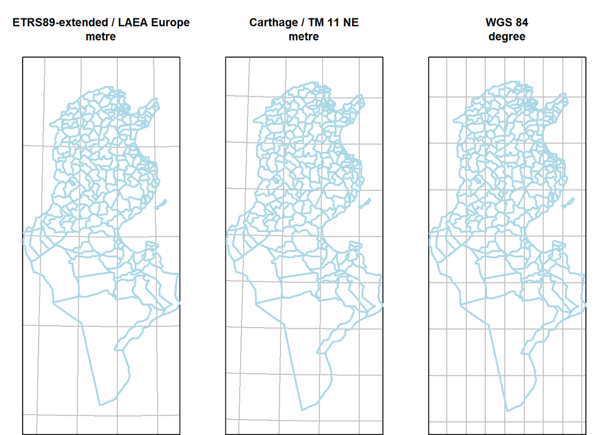

```r
# Initalisation de la fenêtre graphique
par(mfrow = c(1,3),
    mar = c(0, 2, 5, 2),
    xaxs='i', yaxs='i')

# Afficher les délégations avec la projection initiale

# On dessine les géométries dans leur projection d'origine
plot(st_geometry(del), border = "lightblue", lwd = 2, col = NA,
     graticule = TRUE)

# On ajoute en titre le nom de la projection et les unités de mesure
title(paste0(crsDel$Name, "\n", crsDel$units_gdal))


# Carthage - EPSG:2088
plot(st_geometry(del2088), border = "lightblue", lwd = 2, col = NA,
     graticule = TRUE)

title(paste0(st_crs(del2088, parameters = TRUE)$Name, "\n",
             st_crs(del2088, parameters = TRUE)$units_gdal)
     )


# WGS84 EPSG:4326
plot(st_geometry(del4326), border = "lightblue", lwd = 2, col = NA,
     graticule = TRUE)

title(paste0(st_crs(del4326, parameters = TRUE)$Name, "\n",
             st_crs(del4326, parameters = TRUE)$units_gdal)
     )
```

Pour conserver la projection adaptée à la tunisie on reprojete `del` en EPSG:2088

```r
del <- st_transform(del, crs = "EPSG:2088")

st_crs(del, parameters = TRUE)$Name
```

```
[1] "Carthage / TM 11 NE"
```

# Sélections et jointure attributaire

## Sélectionner par attributs

Comme les `data.frame` on peut sélectionner des lignes et des colonnes des objets `sf` en utilisant les crochets :

`monSF[lignes , colonnes]`

### Selectionner des lignes

On peut donc afficher les 5 premières lignes de l’objet `del` grace à leur index

```r
del[1:5,]
```

```
Simple feature collection with 5 features and 11 fields
Geometry type: MULTIPOLYGON
Dimension:     XY
Bounding box:  xmin: 275294.7 ymin: 3827226 xmax: 467583.4 ymax: 4087746
Projected CRS: Carthage / TM 11 NE
  del_code del_nom_fr del_code_riate del_code_ins del_nom_ar gou_code  gou_nom
1 TN.SF.AG     Agareb         TS2146        TN347      عقارب    TN.SF     Sfax
2 TN.JE.AD Ain Drahem         TS1224        TN225  عين دراهم    TN.JE Jendouba
3 TN.SS.AK     Akouda         TS2115        TN316      اكودة    TN.SS   Sousse
4 TN.KR.AL       Alaa         TS2216        TN417     العلاء    TN.KR Kairouan
5 TN.BJ.AM     Amdoun         TS1212        TN213      عمدون    TN.BJ     Beja
  gou_cap gou_cap_dist reg_code      reg_nom                           geom
1       0         30.1       CE   Centre-est MULTIPOLYGON (((462201.4 38...
2       0         38.5       NO   Nord-ouest MULTIPOLYGON (((315372.8 40...
3       0         14.3       CE   Centre-est MULTIPOLYGON (((461740 3974...
4       0         48.6       CO Centre-ouest MULTIPOLYGON (((394811.9 39...
5       0         18.9       NO   Nord-ouest MULTIPOLYGON (((334323 4081...
```

On peut aussi les sélectionner en fonction d’une valeur de champ. Par exemple :

```r
del[del$del_nom_fr == "Sousse Medina", ]
```

```
Simple feature collection with 1 feature and 11 fields
Geometry type: MULTIPOLYGON
Dimension:     XY
Bounding box:  xmin: 463418.8 ymin: 3961466 xmax: 469492.5 ymax: 3969566
Projected CRS: Carthage / TM 11 NE
    del_code    del_nom_fr del_code_riate del_code_ins   del_nom_ar gou_code
242 TN.SS.SM Sousse Medina         TS2110        TN311 سوسة المدينة    TN.SS
    gou_nom gou_cap gou_cap_dist reg_code    reg_nom
242  Sousse       1            1       CE Centre-est
                              geom
242 MULTIPOLYGON (((464400.5 39...
```

### Selectionner des colonnes

```r
del[, ncol(del)-5:ncol(del)]
```

```
Simple feature collection with 266 features and 7 fields
Geometry type: MULTIPOLYGON
Dimension:     XY
Bounding box:  xmin: 178843.6 ymin: 3345448 xmax: 556132.1 ymax: 4132739
Projected CRS: Carthage / TM 11 NE
First 10 features:
     gou_nom gou_code     del_nom_ar del_code_ins del_code_riate
1       Sfax    TN.SF          عقارب        TN347         TS2146
2   Jendouba    TN.JE      عين دراهم        TN225         TS1224
3     Sousse    TN.SS          اكودة        TN316         TS2115
4   Kairouan    TN.KR         العلاء        TN417         TS2216
5       Beja    TN.BJ          عمدون        TN213         TS1212
6     Ariana    TN.AN أريانة المدينة        TN121         TS1120
7  Kasserine    TN.KS         العيون        TN428         TS2227
8      Tunis    TN.TU        باب بحر        TN113         TS1112
9      Tunis    TN.TU      باب سويقة        TN114         TS1113
10  Jendouba    TN.JE    بلطة بوعوان        TN229         TS1228
         del_nom_fr del_code                           geom
1            Agareb TN.SF.AG MULTIPOLYGON (((462201.4 38...
2        Ain Drahem TN.JE.AD MULTIPOLYGON (((315372.8 40...
3            Akouda TN.SS.AK MULTIPOLYGON (((461740 3974...
4              Alaa TN.KR.AL MULTIPOLYGON (((394811.9 39...
5            Amdoun TN.BJ.AM MULTIPOLYGON (((334323 4081...
6      Ariana Ville TN.AN.AR MULTIPOLYGON (((428017.4 40...
7             Ayoun TN.KS.AY MULTIPOLYGON (((319476.8 39...
8          Bab Bhar TN.TU.BB MULTIPOLYGON (((427125.6 40...
9        Bab Souika TN.TU.BS MULTIPOLYGON (((425857.3 40...
10 Balta Bou Aouane TN.JE.BB MULTIPOLYGON (((323552 4060...
```

On peut aussi les selectionner par leur nom

```r
del[, c("del_nom_fr", "gou_nom", "reg_nom")]
```

```
Simple feature collection with 266 features and 3 fields
Geometry type: MULTIPOLYGON
Dimension:     XY
Bounding box:  xmin: 178843.6 ymin: 3345448 xmax: 556132.1 ymax: 4132739
Projected CRS: Carthage / TM 11 NE
First 10 features:
         del_nom_fr   gou_nom      reg_nom                           geom
1            Agareb      Sfax   Centre-est MULTIPOLYGON (((462201.4 38...
2        Ain Drahem  Jendouba   Nord-ouest MULTIPOLYGON (((315372.8 40...
3            Akouda    Sousse   Centre-est MULTIPOLYGON (((461740 3974...
4              Alaa  Kairouan Centre-ouest MULTIPOLYGON (((394811.9 39...
5            Amdoun      Beja   Nord-ouest MULTIPOLYGON (((334323 4081...
6      Ariana Ville    Ariana     Nord-est MULTIPOLYGON (((428017.4 40...
7             Ayoun Kasserine Centre-ouest MULTIPOLYGON (((319476.8 39...
8          Bab Bhar     Tunis     Nord-est MULTIPOLYGON (((427125.6 40...
9        Bab Souika     Tunis     Nord-est MULTIPOLYGON (((425857.3 40...
10 Balta Bou Aouane  Jendouba   Nord-ouest MULTIPOLYGON (((323552 4060...
```

### Combiner les selections

Enfin on peut combiner les selections

```r
delSousse <- del[del$gou_nom %in% "Sousse", c("del_nom_fr", "gou_nom", "reg_nom")]

delSousse
```

```
Simple feature collection with 16 features and 3 fields
Geometry type: MULTIPOLYGON
Dimension:     XY
Bounding box:  xmin: 422897.2 ymin: 3933116 xmax: 469492.5 ymax: 4028665
Projected CRS: Carthage / TM 11 NE
First 10 features:
       del_nom_fr gou_nom    reg_nom                           geom
3          Akouda  Sousse Centre-est MULTIPOLYGON (((461740 3974...
36       Bouficha  Sousse Centre-est MULTIPOLYGON (((458390.3 40...
67        Enfidha  Sousse Centre-est MULTIPOLYGON (((452021.2 40...
100 Hammam Sousse  Sousse Centre-est MULTIPOLYGON (((461739.9 39...
107        Hergla  Sousse Centre-est MULTIPOLYGON (((452737.5 39...
124  Kalaa Kebira  Sousse Centre-est MULTIPOLYGON (((454231.3 39...
125 Kalaâ Seghira  Sousse Centre-est MULTIPOLYGON (((459976.1 39...
138        Kondar  Sousse Centre-est MULTIPOLYGON (((439303 3970...
181        Msaken  Sousse Centre-est MULTIPOLYGON (((457987.4 39...
221   Sid Bou Ali  Sousse Centre-est MULTIPOLYGON (((455032.2 39...
```

Et on peut afficher cette sélection

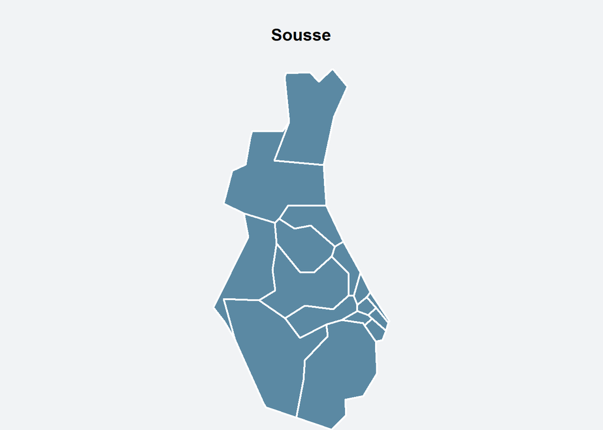

```r
# Parametre de l'affichage
par(mar = c(0, 0, 4, 0),  xaxs='i', yaxs='i', bg = "#F1F3F5")

plot(st_geometry(delSousse), col = "#5B89A3", border = "white", lwd = 2)
title(paste(unique(delSousse$gou_nom)))
```

## Jointure attributaire

Avec la fonction `merge()` on peut joindre les données d’un autre `data.frame` à un objet `sf` et inversement via un champ de jointure commun.

On importe d’autres données du projet

```r
# Importer les fichiers locaux
del_df <- read.csv("data/tun/don_del.csv", sep = ";", dec = ",")
```

On identifie le champ de jointure

```r
del[1:2,]
```

```
Simple feature collection with 2 features and 11 fields
Geometry type: MULTIPOLYGON
Dimension:     XY
Bounding box:  xmin: 275294.7 ymin: 3827226 xmax: 467583.4 ymax: 4087746
Projected CRS: Carthage / TM 11 NE
  del_code del_nom_fr del_code_riate del_code_ins del_nom_ar gou_code  gou_nom
1 TN.SF.AG     Agareb         TS2146        TN347      عقارب    TN.SF     Sfax
2 TN.JE.AD Ain Drahem         TS1224        TN225  عين دراهم    TN.JE Jendouba
  gou_cap gou_cap_dist reg_code    reg_nom                           geom
1       0         30.1       CE Centre-est MULTIPOLYGON (((462201.4 38...
2       0         38.5       NO Nord-ouest MULTIPOLYGON (((315372.8 40...
```

```r
del_df[1:2,]
```

```
  del_code      del_nom_fr     del_nom_ar gou_code gou_nom gou_cap gou_cap_dist
1 TN.AN.AR    Ariana Ville أريانة المدينة       AN  Ariana       1          1.0
2 TN.AN.ET Cité Ettathamen     حي التضامن       AN  Ariana       0          8.8
  reg_code  reg_nom popto_2004 popco_2004 immig_2004 emigr_2004 mobil_2004
1       NE Nord-est      97687      97687      16961      15426      32387
2       NE Nord-est      78311      78311       5651       5245      10896
  menag_2004 ordin_2004 porta_2004 telef_2004 popto_2014 popco_2014 immig_2014
1      27468       9751      22524      18596     114486     114486      15637
2      11950        430       4505       3824      84312      84312       5028
  emigr_2014 mobil2014 menag_2014 ordin_2014 porta_2014 telef_2014 popto_2010
1      20448     36085      32498      25474      32308      19942     109500
2       6752     11780      22087       6836      21715       3496      82922
  surfa_2010 idr_2011
1     18.612    0.638
2      3.376    0.386
```

Ici les deux colonnes identiques ont aussi le même nom. On choisi d’utiliser les codes pour la jointure :

```r
delMerge <- merge(x = del,
                  y = del_df,
                  by.x = "del_code",
                  by.y = "del_code",
                  all.x = TRUE)
```

Attention, le sens de la jointure est important. Ici l’objet “x” est l’objet auquel on joint le second. L’objet final prend le type de l’objet x. Ici nous avons créé un nouvel objet `delMerge` qui résulte de la jointure de `del_def` à `del`. `del_merge`prend donc le type de `del`. C’est un objet`sf`.

La ligne `all.x` signifie que l’on conserve tous les individus du tableau “x” meme si la correspondance est manquante dans le tableau “y”.

```r
# Les deux objets ont bien été joints
head(delMerge, 3)
```

```
Simple feature collection with 3 features and 40 fields
Geometry type: MULTIPOLYGON
Dimension:     XY
Bounding box:  xmin: 411876.4 ymin: 4075789 xmax: 429940.1 ymax: 4109337
Projected CRS: Carthage / TM 11 NE
  del_code       del_nom_fr.x del_code_riate del_code_ins   del_nom_ar.x
1 TN.AN.AR       Ariana Ville         TS1120        TN121 أريانة المدينة
2 TN.AN.ET    Cité Ettathamen         TS1125        TN126     حي التضامن
3 TN.AN.KA kalaât El Andalous         TS1123        TN124   قلعة الاندلس
  gou_code.x gou_nom.x gou_cap.x gou_cap_dist.x reg_code.x reg_nom.x
1      TN.AN    Ariana         1            1.0         NE  Nord-est
2      TN.AN    Ariana         0            8.8         NE  Nord-est
3      TN.AN    Ariana         0           19.8         NE  Nord-est
        del_nom_fr.y   del_nom_ar.y gou_code.y gou_nom.y gou_cap.y
1       Ariana Ville أريانة المدينة         AN    Ariana         1
2    Cité Ettathamen     حي التضامن         AN    Ariana         0
3 kalaât El Andalous   قلعة الاندلس         AN    Ariana         0
  gou_cap_dist.y reg_code.y reg_nom.y popto_2004 popco_2004 immig_2004
1            1.0         NE  Nord-est      97687      97687      16961
2            8.8         NE  Nord-est      78311      78311       5651
3           19.8         NE  Nord-est      23045      15313        728
  emigr_2004 mobil_2004 menag_2004 ordin_2004 porta_2004 telef_2004 popto_2014
1      15426      32387      27468       9751      22524      18596     114486
2       5245      10896      11950        430       4505       3824      84312
3        528       1256       4709        188       1865        829      26796
  popco_2014 immig_2014 emigr_2014 mobil2014 menag_2014 ordin_2014 porta_2014
1     114486      15637      20448     36085      32498      25474      32308
2      84312       5028       6752     11780      22087       6836      21715
3      18211       1104        752      1856       6554       1701       6305
  telef_2014 popto_2010 surfa_2010 idr_2011                           geom
1      19942     109500     18.612    0.638 MULTIPOLYGON (((428017.4 40...
2       3496      82922      3.376    0.386 MULTIPOLYGON (((420275.4 40...
3        428      24367    188.206    0.383 MULTIPOLYGON (((423864.5 41...
```

# Sélections et jointure spatiale

## Sélections spatiales

Les sélections spatiales s’exécutent avec la fonction `st_filter()` et selon les prédicats géométriques suivants :

- `st_intersects()`
- `st_disjoint()`
- `st_touches()`
- `st_crosses()`
- `st_within()`
- `st_contains()`
- `st_contains_properly()`
- `st_overlaps()`
- `st_equals()`
- `st_covers()`
- `st_covered_by()`
- `st_equals_exact()`
- `st_is_within_distance()`

**Tip**

Voir la [vignette sf](https://r-spatial.github.io/sf/reference/geos_binary_pred.html)

On importe les géométries extraites de OSM dans le module sur la Manipulation des données

**Tip**

Pour plus de détail sur l’extraction de données OSM voir le notebook de R. Ysebaert conçu pour l’école thématique : Acquisition de données géographiques et visualisations de base

```r
# Consulter le contenu du géopackage "tun_osm"
st_layers("data/tun/geom/tun_osm.gpkg")
```

```
Driver: GPKG
Available layers:
  layer_name geometry_type features fields crs_name
1      deleg Multi Polygon      266      7   WGS 84
2       sect Multi Polygon     2104      7   WGS 84
3        poi         Point    11571      4   WGS 84
```

```r
# Charger les données ponctuelles
poi <- st_read("data/tun/geom/tun_osm.gpkg",
               layer = "poi")
# Extrait des données chargées
head(poi)
```

```
Simple feature collection with 6 features and 4 fields
Geometry type: POINT
Dimension:     XY
Bounding box:  xmin: 5.364165 ymin: 33.23918 xmax: 10.86563 ymax: 43.31226
Geodetic CRS:  WGS 84
     osm_id          amenity             name_ar                     name_fr
1 255880618   ferry_terminal   محطة آرنك البحرية                        <NA>
2 262728007          parking                <NA>                        <NA>
3 283583078         pharmacy   الصيدلية المركزية          Pharmacie Centrale
4 283658474   ferry_terminal                <NA>                        <NA>
5 290891538             bank بنك قطر الوطني تونس Qatar National Bank Tunisia
6 297765095 place_of_worship             الغريبة      Synagogue de la Ghriba
                       geom
1 POINT (5.364165 43.31226)
2 POINT (10.86563 33.23918)
3 POINT (10.18092 36.83346)
4 POINT (10.30467 36.80743)
5  POINT (10.5971 35.83918)
6 POINT (10.85939 33.81392)
```

Pour que la sélection spatiale fonctionne il faut s’assurer que les deux objets possèdent le meme système de coordonnées de référence

```r
# Nom du SCR de "del"
st_crs(del, parameters = TRUE)$srid
```

```
[1] "EPSG:2088"
```

```r
# Nom du SCR de "poi"
st_crs(poi, parameters = TRUE)$srid
```

```
[1] "EPSG:4326"
```

Ici ils ne concordent pas donc :

```r
# Re projection en
poi <- st_transform(poi, crs = "EPSG:2088")

# Verification du SCR
st_crs(poi, parameters = TRUE)$srid
```

```
[1] "EPSG:2088"
```

On peut maintenant réaliser notre sélection spatiale. Ici on va sélectionner les points qui se trouvent dans l’objet `delSousse` que l’on a construit plus haut.

```r
poiSousse <- st_filter(x = poi,
                       y = delSousse,
                       .predicate = st_within)
```

On visualise le résultat

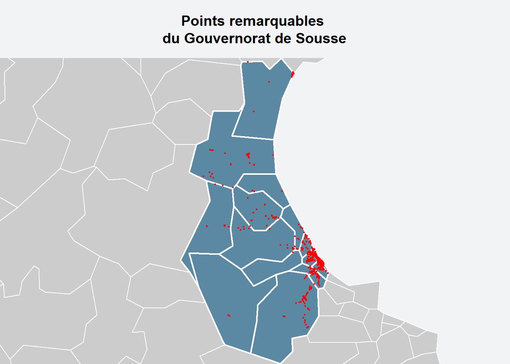

```r
# Parametre de l'affichage
par(mar = c(0, 0, 4, 0),  xaxs='i', yaxs='i', bg = "#F1F3F5")

# Initialisation de la carte à l'emprise de Sousse
plot(st_geometry(delSousse), col = NA, border = NA)

# Fond de carte des délégations
plot(st_geometry(del), col = "gray80", border = "white", lwd = 1, add = TRUE)

# Délégations de Soussz
plot(st_geometry(delSousse), col = "#5B89A3", border = "white", lwd = 2, add = TRUE)

# Points remarquables de Souss
plot(st_geometry(poiSousse), col = "red", border = "white", pch = 19, cex = .3, add = TRUE)

# Titre
title("Points remarquables \ndu Gouvernorat de Sousse")
```

# Opérations sur les géométries

## Extraction de centroides

La fonction `st_centroid()` permet d’extraire les centroides des polygones.

Ici on extrait les centroides des délégations de Sousse :

```r
delSousse_c <- st_centroid(delSousse)
```

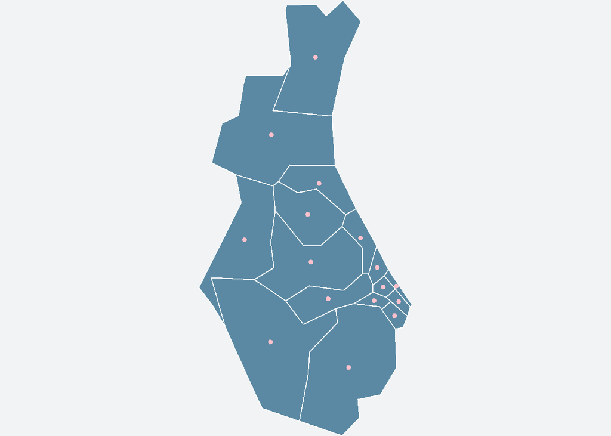

```r
# Parametre de l'affichage
par(mar = c(0, 0, 0, 0),  xaxs='i', yaxs='i', bg = "#F1F3F5")

# Délégations de Sousse
plot(st_geometry(delSousse), col = "#5B89A3", border = "white")

# Centroides des délégations de Sousse
plot(st_geometry(delSousse_c), add = TRUE, pch = 20, col = "pink")
```

## Agrégation de polygones

### Agrégation spatiale

La fonction `st_union()` permet d’agréger des polygones entre eux. Par exemple pour reconstituer le gouvernorat de Sousse

```r
gouSousse <- st_union(delSousse)
```

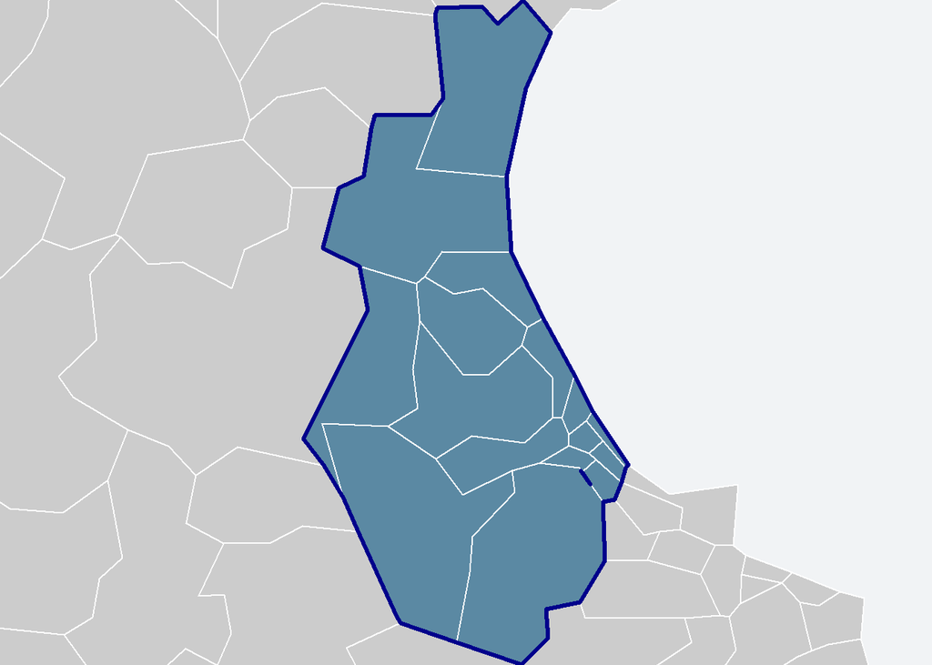

```r
# Parametre de l'affichage
par(mar = c(0, 0, 0, 0),  xaxs='i', yaxs='i', bg = "#F1F3F5")

# Initialisation de la carte à l'emprise de Sousse
plot(st_geometry(delSousse), col = NA, border = NA)

# Fond de carte des délégations
plot(st_geometry(del), col = "gray80", border = "white", lwd = 1, add = TRUE)

# Délégations de Sousse
plot(st_geometry(delSousse), col = "#5B89A3", border = "white", lwd = 1, add = TRUE)

# Gouvernorat de Sousse
plot(st_geometry(gouSousse), border = "darkblue", lwd = 3, add = TRUE)
```

### Agrégation spatiale et attributaire

On peut aussi agréger les polygones et demander un résumé statistique pour un ou plusieurs champ décrivant ces polygones. Plusieurs méthodes permettent de réaliser cet objectif.

La première méthode mobilise la fonction `aggregate()` de `sf`. Cette fonction permet d’agréger les polygones et de demander **le même résumé statistique** pour plusieurs champs.

Dans cet exemple nous repartons de l’objet `delMerge` issu de la fusion entre les géométries des délégations et le tableau additionnel. L’objectif est de construire un objet `gou` représentant les gouvernorats et leur population. Pour y arriver, nous fusionnons toutes les délégations via le champ `gou_nom.x` et calculons la somme de la population pour chacun.

```r
gou <- aggregate(
  x = delMerge[c("popto_2014", "immig_2014")],
  by = list(gou_nom = delMerge$gou_nom.x),
  FUN = sum
)
```

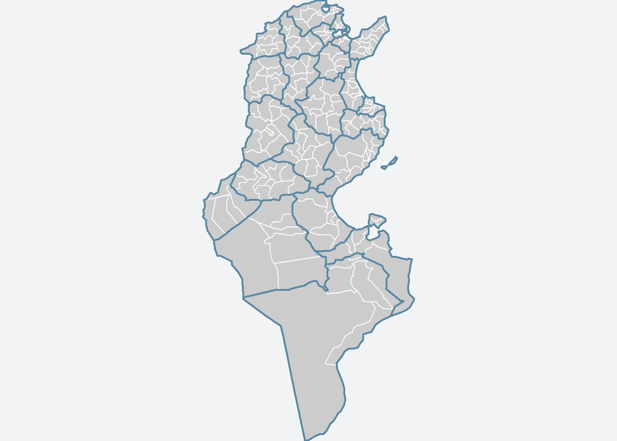

```r
# Parametre de l'affichage
par(mar = c(0, 0, 0, 0),  xaxs='i', yaxs='i', bg = "#F1F3F5")

# Fond de carte des délégations
plot(st_geometry(del), col = "gray80", border = "white", lwd = 1)

# Gouvernorats
plot(st_geometry(gou), border = "#5B89A3", lwd = 2, add = TRUE)
```

Les fonctions `group_by()` et `summarise()` du package `dplyr` permettent d’agréger les polygones en demandant des résumés statistiques **différents** selon les champs.

```r
library(dplyr)

gou <- delMerge |>
  group_by(gou_nom.x) |>
  summarise(pop = sum(popto_2014),
            immig_mean = mean(immig_2014))
```

```r
gou[1:3, ]
```

```
Simple feature collection with 3 features and 3 fields
Geometry type: POLYGON
Dimension:     XY
Bounding box:  xmin: 313571.7 ymin: 4026799 xmax: 445046.3 ymax: 4113741
Projected CRS: Carthage / TM 11 NE
# A tibble: 3 × 4
  gou_nom.x    pop immig_mean                                               geom
  <chr>      <int>      <dbl>                                      <POLYGON [m]>
1 Ariana    576088     11297. ((419782.2 4077626, 419782.2 4077626, 419782.2 40…
2 Beja      303032      1049. ((350635.1 4027850, 350635.1 4027850, 350635.1 40…
3 Ben Arous 631842      6088  ((442640 4056428, 442640 4056428, 442640 4056428,…
```

## Construction d’une zone tampon (buffer)

Pour construire la zone tampon il est préférable de connaître le SCR et l’unité de mesure de l’objet `sf`, par exemple avec cette fonction.

```r
st_crs(delSousse_c)$units
```

```
[1] "m"
```

Les mesures sont exprimées en metres, on peut à présent utiliser la fonction `st_buffer()` pour construire la zone tampon.

Ici on peut construire une zone tampon autour du centroide de la délégation de Sidi Bou Ali

```r
# Sélection du centroide de Sidi Bou Ali
sidiBou_c <- delSousse_c[delSousse_c$del_nom_fr %in% "Sid Bou Ali", ]
```

```r
sidiBou_t <- st_buffer(sidiBou_c, dist = 5000)
```

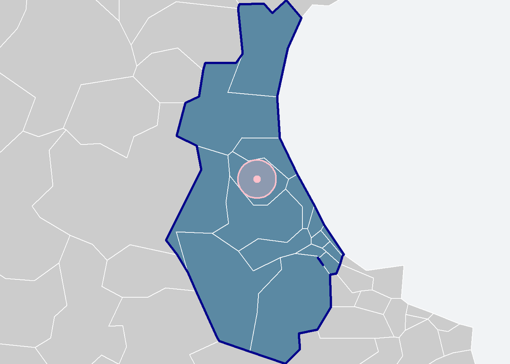

```r
# Parametre de l'affichage
par(mar = c(0, 0, 0, 0),  xaxs='i', yaxs='i', bg = "#F1F3F5")

# Initialisation de la carte à l'emprise de Sousse
plot(st_geometry(delSousse), col = NA, border = NA)

# Fond de carte des délégations
plot(st_geometry(del), col = "gray80", border = "white", lwd = 1, add = TRUE)

# Délégations de Sousse
plot(st_geometry(delSousse), col = "#5B89A3", border = "white", lwd = 1, add = TRUE)

# Gouvernorat de Sousse
plot(st_geometry(gouSousse), border = "darkblue", lwd = 3, add = TRUE)

# Zone tampon de 5km autour du centroide de Sidi Bou Ali
plot(st_geometry(sidiBou_t), border = "pink", col = "#fac0cb50", lwd = 2, add = TRUE)

# Centroide de Sidi Bou Ali
plot(st_geometry(sidiBou_c), col = "pink", pch = 20, cex = 2, add = TRUE)
```

## Intersection

La fonction `st_intersection()` permet de découper une couche par une autre.

```r
poi_sidiBou <- st_intersection(x = sidiBou_t, y = poiSousse)
```

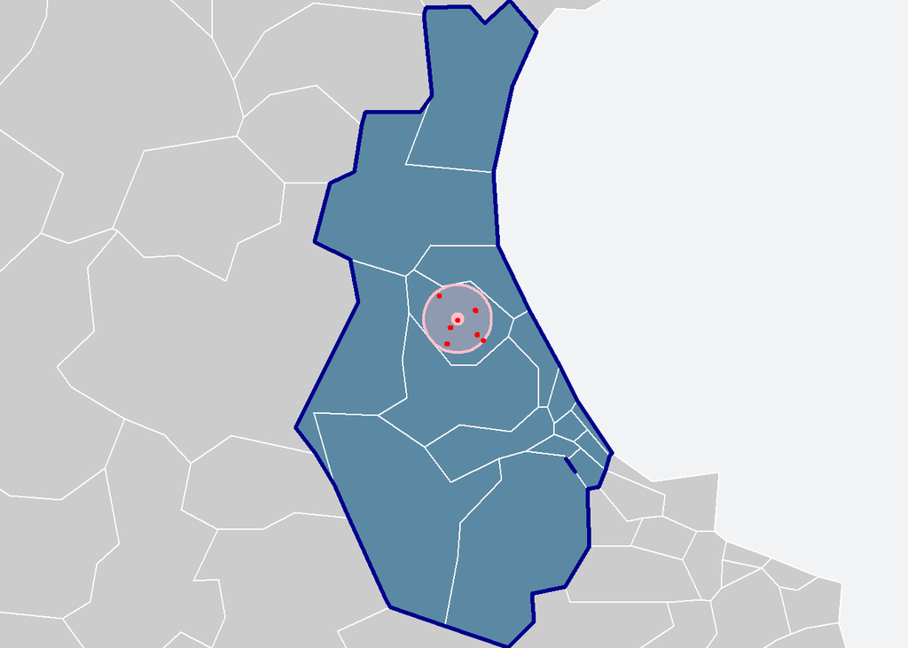

```r
# Parametre de l'affichage
par(mar = c(0, 0, 0, 0),  xaxs='i', yaxs='i', bg = "#F1F3F5")

# Initialisation de la carte à l'emprise de Sousse
plot(st_geometry(delSousse), col = NA, border = NA)

# Fond de carte des délégations
plot(st_geometry(del), col = "gray80", border = "white", lwd = 1, add = TRUE)

# Délégations de Sousse
plot(st_geometry(delSousse), col = "#5B89A3", border = "white", lwd = 1, add = TRUE)

# Gouvernorat de Sousse
plot(st_geometry(gouSousse), border = "darkblue", lwd = 3, add = TRUE)

# Zone tampon de 5km autour du centroide de Sidi Bou Ali
plot(st_geometry(sidiBou_t), border = "pink", col = "#fac0cb50", lwd = 2, add = TRUE)

# Centroide de Sidi Bou Ali
plot(st_geometry(sidiBou_c), col = "pink", pch = 20, cex = 2, add = TRUE)

plot(st_geometry(poi_sidiBou), col = "red", border = "white", pch = 19, cex = .5, add = TRUE)
```

## Compter les points

La fonction `st_intersects()` permet d’intersecter deux couches sans les découper, et de compter les éléments d’une couche (y) contenue dans une autre (x).

L’argument `sparse = TRUE` nous permet de lister pour chaque élément de x les objets de y.

```r
inter <- st_intersects(x = sidiBou_t, y = poi_sidiBou)

inter
```

```
Sparse geometry binary predicate list of length 1, where the predicate
was `intersects'
 1: 1, 2, 3, 4, 5, 6, 7, 8, 9, 10, ...
```

Le `1:` signifie qu’il y a un objet, une 1 liste. Les chiffres suivants sont les identifiants de chacun des points.

Pour vérifier que le nombre d’intersection corresponde bien au nombre d’objets intersectés de x, ici il s’agit de `sidiBou_t` on fait :

```r
length(inter) == nrow(sidiBou_t)
```

```
[1] TRUE
```

Pour compter le nombre de points intersectés par `sidiBou_t` on utilise la fonction `lengths()` qui renvoie la longueurs de chaque liste de l’intersection.

```r
lengths(inter)
```

```
[1] 11
```

On peut ajouter cette information à la table attributaire de sidiBou_t en créant un nouveau champ `nb_poi`

```r
sidiBou_t$nb_poi <- lengths(inter)
```

Sur la base de cet exemple on peut compter les points dans les gouvernorats créé dans la Section 7.2.2

```r
interGou <- st_intersects(x = gou, y = poi)

interGou
```

```
Sparse geometry binary predicate list of length 24, where the predicate
was `intersects'
first 10 elements:
 1: 68, 125, 149, 160, 173, 174, 177, 186, 193, 195, ...
 2: 24, 260, 1206, 1322, 1323, 1708, 1710, 1711, 1712, 1713, ...
 3: 69, 70, 71, 72, 73, 74, 75, 96, 97, 262, ...
 4: 276, 277, 278, 289, 329, 330, 1297, 1597, 1728, 1729, ...
 5: 94, 746, 761, 762, 763, 784, 785, 787, 809, 810, ...
 6: 695, 1215, 1216, 1217, 1218, 1249, 1746, 1747, 1748, 1780, ...
 7: 23, 549, 550, 1544, 1545, 1546, 1547, 1548, 1550, 1551, ...
 8: 19, 261, 364, 505, 506, 764, 765, 766, 767, 768, ...
 9: 1739, 2175, 2985, 2986, 2987, 2988, 3001, 3002, 3003, 3004, ...
 10: 29, 145, 1208, 1219, 1220, 1221, 1222, 1223, 1224, 1225, ...
```

```r
# Le nombre d'intersections est-il égal aux objets de gou
length(interGou) == nrow(gou)
```

```
[1] TRUE
```

```r
# combien y a t il de points par intersection
lengths(interGou)
```

```
 [1]  292  117  705  183  276  225  143  239  277  165   85  277   56  361  508
[16] 1406 1336  262  100  767  316   90 2505   91
```

```r
# Ajout du nombre de points intersectés à l'objet gou
gou$nb_poi <- lengths(interGou)
```

Et on peut cartographier ce résultat avec le package `mapSf`

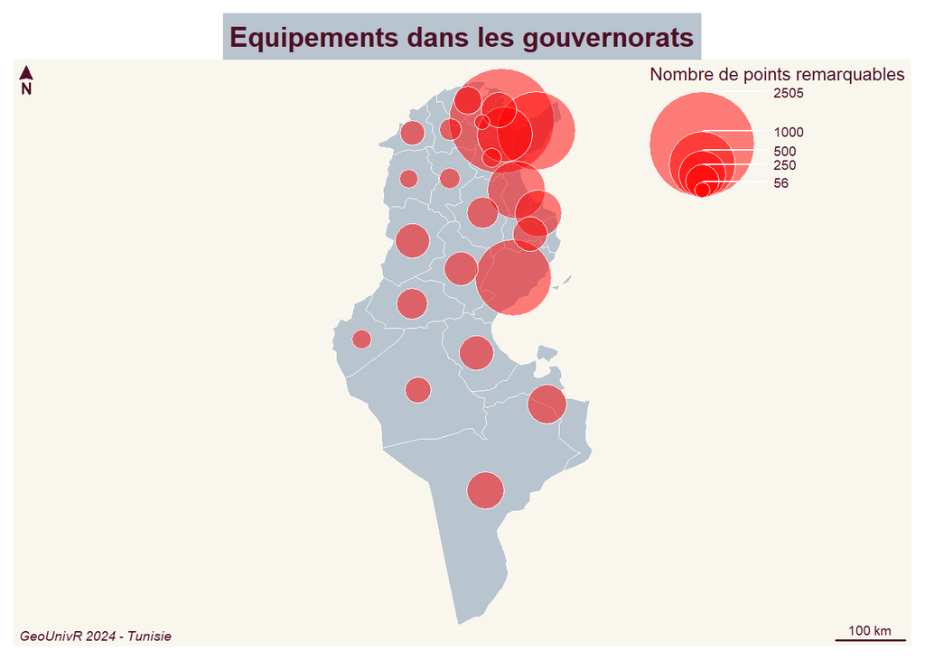

```r
library(mapsf)

# intitialisation du fond de carte
mf_map(x = gou, border = "white", lwd = 0.5)

# cartographie du nombre de points en cercles proportionnels
mf_map(x = gou,
       var = "nb_poi",
       type = "prop",
       border = "white",
       col = "#FF000080",
       leg_title = "Nombre de points remarquables",
       inches   = 0.4, leg_pos  = "topright")

# Habillage
mf_layout(title = "Equipements dans les gouvernorats", arrow = TRUE, scale = TRUE, credits = "GeoUnivR 2024 - Tunisie")
```

**Tip**

Pour plus de détail sur la cartographie avec le package `mapsf` voir le notebook de N. Lambert conçu pour l’école thématique : [Faire des cartes thématiques avec R](https://neocarto.github.io/geounivr2024/MAR_2_carto/index.html#cartographie-avec-sf)

## Changer de type de géométrie

Il est possible de convertir une géométrie en un autre type, par exemple convertir des géométries de type `POLYGON` à `LINESTRING`, avec la fonction `st_cast()` de `sf`.

Pour connaitre le type de géométries

```r
st_geometry_type(del, by_geometry = FALSE)
```

```
[1] MULTIPOLYGON
18 Levels: GEOMETRY POINT LINESTRING POLYGON MULTIPOINT ... TRIANGLE
```

Ici on converti ces `MULTIPOLYGON` en `MULTILINESTRING`

```r
del_line <- st_cast(del, to = "MULTILINESTRING")
```

# Unités de mesures et calculs

Les mesures sont possibles lorsque l’objet `sf` à des coordonnées projetées. La première étape est donc de vérifier le SCR de l’objet et son unité de mesure.

## Unités de mesures

On peut connaitre l’unité de mesure de la projection avec la fonction `st_crs()`

**Détail de `st_crs(del)`**

```r
st_crs(del)
```

```
Coordinate Reference System:
  User input: EPSG:2088
  wkt:
PROJCRS["Carthage / TM 11 NE",
    BASEGEOGCRS["Carthage",
        DATUM["Carthage",
            ELLIPSOID["Clarke 1880 (IGN)",6378249.2,293.466021293627,
                LENGTHUNIT["metre",1]]],
        PRIMEM["Greenwich",0,
            ANGLEUNIT["degree",0.0174532925199433]],
        ID["EPSG",4223]],
    CONVERSION["TM 11 NE",
        METHOD["Transverse Mercator",
            ID["EPSG",9807]],
        PARAMETER["Latitude of natural origin",0,
            ANGLEUNIT["degree",0.0174532925199433],
            ID["EPSG",8801]],
        PARAMETER["Longitude of natural origin",11,
            ANGLEUNIT["degree",0.0174532925199433],
            ID["EPSG",8802]],
        PARAMETER["Scale factor at natural origin",0.9996,
            SCALEUNIT["unity",1],
            ID["EPSG",8805]],
        PARAMETER["False easting",500000,
            LENGTHUNIT["metre",1],
            ID["EPSG",8806]],
        PARAMETER["False northing",0,
            LENGTHUNIT["metre",1],
            ID["EPSG",8807]]],
    CS[Cartesian,2],
        AXIS["(E)",east,
            ORDER[1],
            LENGTHUNIT["metre",1]],
        AXIS["(N)",north,
            ORDER[2],
            LENGTHUNIT["metre",1]],
    USAGE[
        SCOPE["Oil and gas exploration and production."],
        AREA["Tunisia - offshore."],
        BBOX[33.22,7.81,38.41,13.67]],
    ID["EPSG",2088]]
```

Une méthode plus directe consiste à aller chercher précisément cette information dans ce que renvoie cette fonction :

```r
st_crs(del, parameters = TRUE)$units_gdal
```

```
[1] "metre"
```

## Calculs

### Calcul de superficie

Pour calculer la superficie on utilise la fonction `st_area()`. Elle renvoie une valeur dans l’unité de mesure de l’objet `sf`. Ici en metres carrés.

```r
# Superficie des 5 premier-es délégations
st_area(del[1:5, ])
```

```
Units: [m^2]
[1] 715991519 462714091  44463342 805121622 238700382
```

On peut enregistrer cette information dans l’objet

```r
del$area <- st_area(del)
```

### Calcul de longueur

Le calcul de longueur ne s’applique qu’aux types `LINESTRING` et `MULTILINESTRING`.

```r
st_length(del_line[1:5, ])
```

```
Units: [m]
[1] 123930.04 130232.45  34469.44 159296.09  80536.48
```

```r
del_line$perimetre <- st_length(del_line)
```

### Calcul de distance

On peut calculer la distance entre deux points avec la fonction `st_distance()`.

Le résultat du calcul est une matrice de distance entre tous les points.

```r
st_distance(del[1:5, ])
```

```
Units: [m]
          [,1]     [,2]      [,3]      [,4]     [,5]
[1,]      0.00 244010.5 109399.42  91764.93 229873.3
[2,] 244010.51      0.0 167738.93 116685.25      0.0
[3,] 109399.42 167738.9      0.00  62508.93 150025.5
[4,]  91764.93 116685.2  62508.93      0.00 106360.3
[5,] 229873.27      0.0 150025.46 106360.32      0.0
```

Ici l’unité de mesure de la distance est le metre. On peut modifier cette unité grace au package `units` et de la fonction `set_units()`. Il ne s’agit pas ici de modifier l’unité de tout l’objet `sf` mais seulement des objets créés lors des calculs.

Par exemple en reprenant notre calcul de distances en metres dans un nouvel objet :

```r
distances <- st_distance(del[1:5, ])
```

On peut les convertir en kilometres (km)

```r
# Chargement du package
library(units)

# Modification de l'unité
set_units(x = distances, value = km)
```

```
Units: [km]
          [,1]     [,2]      [,3]      [,4]     [,5]
[1,]   0.00000 244.0105 109.39942  91.76493 229.8733
[2,] 244.01051   0.0000 167.73893 116.68525   0.0000
[3,] 109.39942 167.7389   0.00000  62.50893 150.0255
[4,]  91.76493 116.6852  62.50893   0.00000 106.3603
[5,] 229.87327   0.0000 150.02546 106.36032   0.0000
```

Pour que le résultat soit conservé :

```r
distances <- set_units(x = distances, value = km)
```

# Aller plus loin

## Simplifier les géométries

La fonction `st_simplify()` de `sf`permet de généraliser des géométries.

```r
del_simp_sf <- st_simplify(del, dTolerance = 5000, preserveTopology = TRUE)
```

Cett fonction n’est pas la plus éfficiace, on peut préférer utiliser la fonction `ms_simplify()` du package `rmapshaper` permet de généraliser ou simplifier les géométries en préservant la topologie.

```r
library(rmapshaper)

# simple généralisation des géométries
del_simp_rmap <- ms_simplify(del)
```

On peut choisir la proportion de sommets à garder avec l’argument `keep = ...`, et forcer la conservation des formes avec `keep_shapes = TRUE`

```r
# Forte généralisation des géométries
del_simp_rmap2 <- ms_simplify(del, keep = 0.001, keep_shapes = TRUE)
```

Voici une comparaison de généralisation avec différents paramètres et avec la fonction `st_simplify()` de `sf`

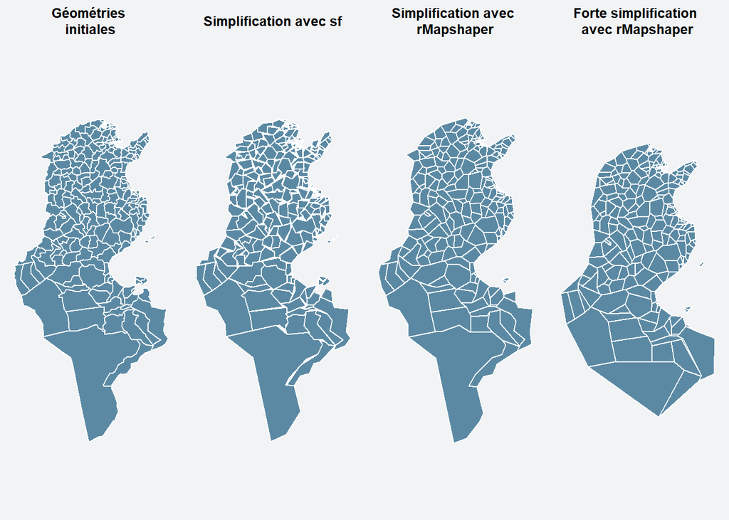

```r
par(mfrow = c(1,4),
    mar = c(0, 1, 3, 1),
    xaxs='i', yaxs='i',
    bg = "#F1F3F5")

plot(del$geom, col = "#5B89A3", border = "white")
title("Géométries \ninitiales")

plot(del_simp_sf$geom, col = "#5B89A3", border = "white")
title("Simplification avec sf")

plot(del_simp_rmap$geom, col = "#5B89A3", border = "white")
title("Simplification avec \nrMapshaper")

plot(del_simp_rmap2$geom, col = "#5B89A3", border = "white")
title("Forte simplification \navec rMapshaper")
```

## Digitalisation

La digitalisation est une étape utile de la manipulation de données spatiales mais n’est pas reproductible.

## Construction d’une grille régulière

La fonction `st_male_grid()` permet la création d’une grille régulière sur l’emprise d’un objet géographique donné.

Cette fonction renvoi un objet de type `sfc` constitué de listes de cellules. Pour le manipuler facilement on le converti en objet `sf` avec la fonction `st_sf()` et en ajoutant un champ d’identifiants.

```r
# Création de la grille
grid <- st_make_grid(gou, cellsize = 35000)

# Ajout d'un identifiant unique et passage en sf
grid <- st_sf(ID = 1:length(grid), geom = grid)

head(grid)
```

```
Simple feature collection with 6 features and 1 field
Geometry type: POLYGON
Dimension:     XY
Bounding box:  xmin: 178843.6 ymin: 3345448 xmax: 388843.6 ymax: 3380448
Projected CRS: Carthage / TM 11 NE
  ID                           geom
1  1 POLYGON ((178843.6 3345448,...
2  2 POLYGON ((213843.6 3345448,...
3  3 POLYGON ((248843.6 3345448,...
4  4 POLYGON ((283843.6 3345448,...
5  5 POLYGON ((318843.6 3345448,...
6  6 POLYGON ((353843.6 3345448,...
```

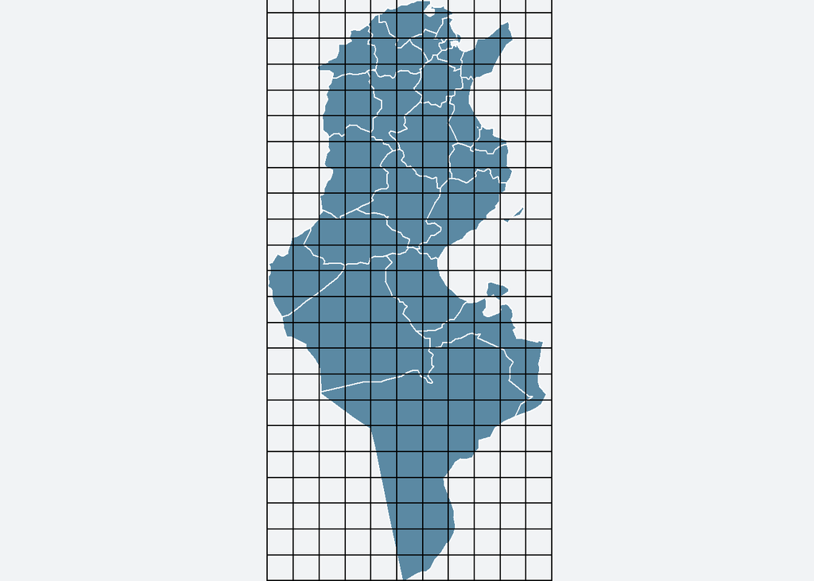

```r
par(mar = c(0, 0, 0, 0), xaxs='i', yaxs='i', bg = "#F1F3F5")
plot(st_geometry(gou), col = "#5B89A3", border = "white", lwd = 1)
plot(st_geometry(grid), col = NA, border = "black", lwd = 1, add = TRUE)
```

Il est possible de créer des grilles hexagonales avec l’argument `square = FALSE`

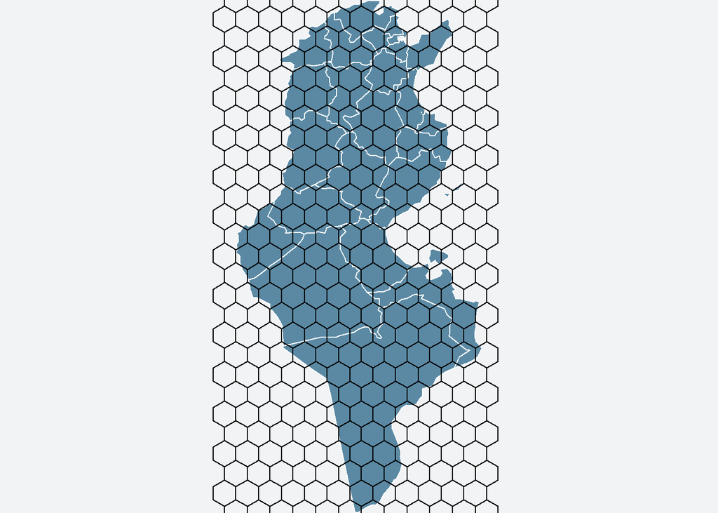

```r
grid_hex <- st_make_grid(gou, cellsize = 35000, square = FALSE)

# Ajout d'un identifiant unique et passage en sf
grid_hex <- st_sf(ID = 1:length(grid_hex), geom = grid_hex)

# Cartographie
par(mar = c(0, 0, 0, 0), xaxs='i', yaxs='i', bg = "#F1F3F5")
plot(st_geometry(gou), col = "#5B89A3", border = "white", lwd = 1)
plot(st_geometry(grid_hex), col = NA, border = "black", lwd = 1, add = TRUE)
```

Ou de récuperer le centroide de ces polygones avec l’argument `what = centers` ou les angles avec `what = corners`

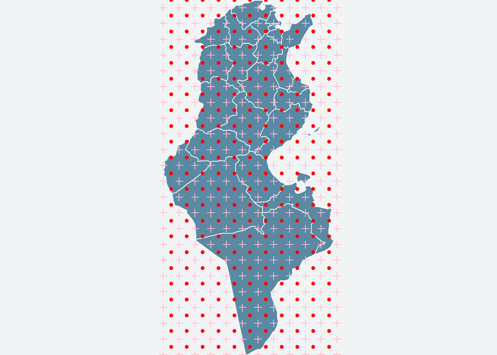

```r
par(mar = c(0, 0, 0, 0), xaxs='i', yaxs='i', bg = "#F1F3F5")

plot(st_geometry(gou), col = "#5B89A3", border = "white", lwd = 1)

# Les centres
plot(st_make_grid(gou, cellsize = 35000, what = "centers"), col = "red", pch = 20, add = TRUE)

# Les angles
plot(st_make_grid(gou, cellsize = 35000, what = "corners"), col = "pink", pch = 3, add = TRUE)
```

### Intersecter la grille avec les points

Comme présenté dans la Section 7.4 on peut intersecter des points dans des polygones et les compter.

```r
# Intersection
inter <- st_intersects(grid, poi, sparse = TRUE)

# vérifier l'intersection
length(inter) == nrow(grid)
```

```
[1] TRUE
```

```r
# Jointure des résultats dans la grille
grid$nb_poi <- lengths(inter)

head(grid)
```

```
Simple feature collection with 6 features and 2 fields
Geometry type: POLYGON
Dimension:     XY
Bounding box:  xmin: 178843.6 ymin: 3345448 xmax: 388843.6 ymax: 3380448
Projected CRS: Carthage / TM 11 NE
  ID                           geom nb_poi
1  1 POLYGON ((178843.6 3345448,...      0
2  2 POLYGON ((213843.6 3345448,...      0
3  3 POLYGON ((248843.6 3345448,...      0
4  4 POLYGON ((283843.6 3345448,...      0
5  5 POLYGON ((318843.6 3345448,...      0
6  6 POLYGON ((353843.6 3345448,...      0
```

On peut affiner cette grille en ne sélectionnant que les carreaux qui intersectent le fond de carte…

```r
grid_f <- st_filter(grid, gou, .predicate = st_intersects)
```

…et cartographier le résultat avec `mapsf`

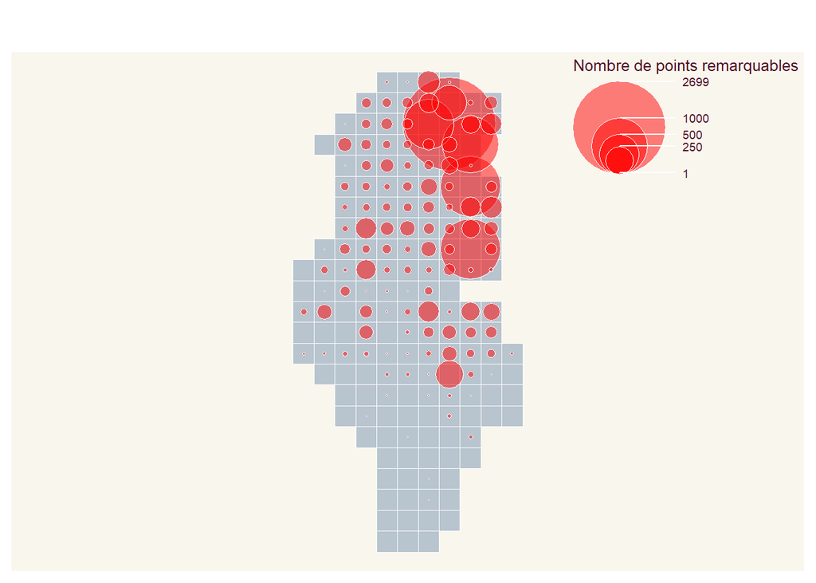

```r
# intitialisation du fond de carte
mf_map(x = grid_f, border = "white", lwd = 0.5)

# cartographie du nombre de points en cercles proportionnels
mf_map(x = grid_f,
       var = "nb_poi",
       type = "prop",
       border = "white",
       col = "#FF000080",
       leg_title = "Nombre de points remarquables",
       inches   = 0.4, leg_pos  = "topright")
```

## Conversion vecteur –> raster

Le package `terra` permet la manipulation de données raster mais aussi de données vecteur pour certains traitements.

On peut convertir un objet vectoriel `sf` vers un objet vectoriel `terra` de format `spatVector` avec la fonction `vect()` de `terra`

```r
library(terra)

grid_spatVect <- vect(grid)
class(grid_spatVect)
```

```
[1] "SpatVector"
attr(,"package")
[1] "terra"
```

On peut aussi convertir un objet vectoriel `sf` vers un objet raster `terra` de format `spatRast` pour cela voir le module de raster

**A propos de ce document**

Ce support a été créé pour la semaine de formation franco-tunisienne **GEO UNIV’R Tunisie 2024 - “Enseigner la statistique, la cartographie et l’analyse spatiale avec R** qui se tient à Sousse en mai 2024.

#### Références

Giraud, Timothée, and Hugues Pecout. 2024. *Géomatique avec R*. https://doi.org/https://doi.org/10.5281/zenodo.5906212.

Pebesma, Edzer, and Roger Bivand. 2023. *Spatial Data Science: With Applications in r*. Chapman; Hall/CRC. https://doi.org/10.1201/9780429459016.